# Spatial Autocorrelation for Categorical Variables

#### Here is a map of the election results. States won by Bush are shown in black and states won by Gore are shown in white.

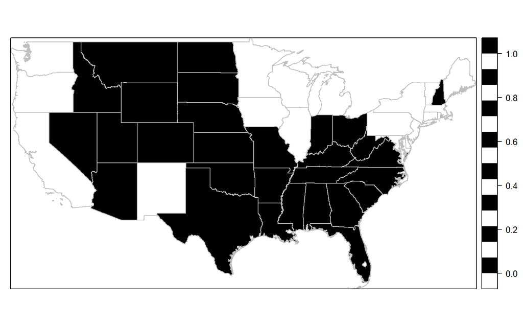

```r
spplot(shp, "BUSH", col="grey", col.regions=c("white", "black"))
```

```r
smallestnbcard<-card(queen)
sum(smallestnbcard)
```

```
## [1] 214
```

### **Hypotheses**

#### Here, we have two hypotheses for J<sub>WW</sub> and two for J<sub>BB</sub>:

#### *For J<sub>WW</sub> (States where Gore won: `shp@data$BUSH = 0`)*:

#### **H<sub>0</sub>**: Observed J<sub>WW</sub> count = Expected J<sub>WW</sub> count

#### **H<sub>A</sub>**: Observed J<sub>WW</sub> count > Expected J<sub>WW</sub> count

#### If p < 0.05 then reject H<sub>0</sub> for H<sub>A</sub>

#### *For J<sub>BB</sub> (States where Bush won: `shp@data$BUSH = 1`)*:

#### **H<sub>0</sub>**: Observed J<sub>BB</sub> count = Expected J<sub>BB</sub> count

#### **H<sub>A</sub>**: Observed J<sub>BB</sub> count > Expected J<sub>BB</sub> count

#### If p < 0.05 then reject H<sub>0</sub> for H<sub>A</sub>

```r
joincount.test(factor(shp@data$BUSH), queenmat.nb2listw, alternative = "greater")
```

```
##
##  Join count test under nonfree sampling
##
## data:  factor(shp@data$BUSH)
## weights: queenmat.nb2listw
##
## Std. deviate for 0 = 1.8195, p-value = 0.03442
## alternative hypothesis: greater
## sample estimates:
## Same colour statistic           Expectation              Variance
##              22.00000              16.22074              10.08890
##
##
##  Join count test under nonfree sampling
##
## data:  factor(shp@data$BUSH)
## weights: queenmat.nb2listw
##
## Std. deviate for 1 = 4.8039, p-value = 0.0000007779
## alternative hypothesis: greater
## sample estimates:
## Same colour statistic           Expectation              Variance
##              58.00000              38.51241              16.45589
```

#### In our results, we see that the states where Gore won (i.e.,`shp@data$BUSH = 0`), the z-score is 1.8195. This can be calculated as

$$\frac{J_{WW} - E(J_{WW})}{\sigma_{J_{WW}}} = \frac{22 - 16.22074}{\sqrt{10.08890}} = 1.8195$$

#### From this z-statistic, we get a one-sided p-value of 0.03442 from the standard normal table. That means that we can reject H<sub>0</sub> for H<sub>A</sub>.

#### On the other hand, for the states where Bush won (i.e., `shp@data$BUSH = 1`), the z-score is 4.8039. This can be calculated as

$$\frac{J_{BB} - E(J_{BB})}{\sigma_{J_{BB}}} = \frac{58 - 38.51241}{\sqrt{16.45589}} = 4.8039$$

#### From this z-statistic, we get a one-sided p-value of <0.0001. Once again, this means that we can reject H<sub>0</sub> for H<sub>A</sub>.

#### In other words, there is evidence that the states where Gore won are clustered in space, and states where Bush won are clustered in space.

#### Keep in mind that if we wanted our alternative hypothesis to test for negative spatial autocorrelation, we would use the `alternative = "less"` option in the `joincount.test` command above. And if we want our alternative hypothesis to be two-sided, then we could do this using the `alternative = "two.sided"` option.

#### Another thing to notice from the output above: the observed number of boundaries between states where Gore won is 22 and the observed number of boundaries between states where Bush won is 58. Because we saw above that the total number of boundaries between states is 107, we can also calculate the observed number of boundaries between states where Bush won and states where Gore won as 107 - (22+58) = 27.

## Categorical variables with more than two categories

#### What happens if you have a categorical variable with more than two categories? In that case, the test is performed for every category. For example, imagine you want to look at whether there is clustering of states which are solid Democrat (blue states), states which are solid Republican (red states), and swing states (purple states). In that case, the command joincount.test tests the following hypotheses:

#### *Blue States*:

#### **H<sub>0</sub>**: Blue states aren’t clustered with other blue states

#### **H<sub>A</sub>**: Blue states are clustered with other blue states

#### *Red States*:

#### **H<sub>0</sub>**: Red states aren’t clustered with other red states

#### **H<sub>A</sub>**: Red states are clustered with other red states

#### *Purple States*:

#### **H<sub>0</sub>**: Purple states aren’t clustered with other purple states

#### **H<sub>A</sub>**: Purple states are clustered with other purple states

#### Everything else remains the same and the syntax of the `joincount.test` command above remains the unchanged.

Information adapted by Eugene Brusilovskiy from the slides of Dr. Ronald Briggs at the University of Texas at Dallas

10/18/2019